# Differential Expression Analysis with EdgeR

Carson Stacy & Jeffrey Lewis

Fall 2023

last updated: 2023-08-08

# Getting Things Setup

As usual, make sure we have the right packages for this exercise

```r
list.of.packages <- c("tidyverse", "here", "knitr", "pander", "BiocManager", "reactable")

new.packages <- list.of.packages[!(list.of.packages %in% installed.packages()[,"Package"])]
if(length(new.packages)) install.packages(new.packages,repos = "http://cran.us.r-project.org")
lapply(list.of.packages, require, character.only = TRUE)
```

We also need the bioconductor package “edgeR” for today’s activity.

```r
# make sure we have the CRAN package installed for getting bioconductor packages
if (!requireNamespace("edgeR", quietly = TRUE))
    BiocManager::install("edgeR")

# this loads the saccharomyces cerevesiae database from sgd
if (!requireNamespace("org.Sc.sgd.db", quietly = TRUE))
    BiocManager::install("org.Sc.sgd.db")
```

# Description

This will be our first differential expression analysis workflow, converting gene counts across samples into meaningful information about genes that appear to be significantly differentially expressed between samples

# Learning outcomes

At the end of this exercise, you should be able to:

- Generate a table of sample metadata .
- Filter low counts and normalize count data.
- Utilize the edgeR package to identify differentially expressed genes.

```r
library(edgeR)
library(org.Sc.sgd.db)
# for ease of use, set max number of digits after decimal
options(digits=3)
```

# Loading in the featureCounts object

We saved this file at the end of last exercise (Read_Counting.Rmd). Now we can load that object back in and assing it to the variable fc. Be sure to change the file path if you have saved it in a different location.

```r
fc <- readRDS(file = "~/Desktop/yeast_fc_output.Rds")
```

```
## Error in gzfile(file, "rb"): cannot open the connection
```

If you don’t have that file for any reason, the below code chunk will load a copy of it from Github.

```r
if( !exists("fc") )
{
  fc <- read_rds('https://github.com/clstacy/GenomicDataAnalysis_Fa23/raw/main/data/heat_shock/yeast_fc_output.Rds')
}
```

So far, we’ve been able to process all of the fastq files without much information about what each sample is in the experimental design. Now, we need the metadata for the samples

```r
sample_metadata <- tribble(
  ~FileName,                                                    ~GEOAccession, ~Condition,
  "filtered_subset_phenol_heat_rep1_rfastp_R1.fastq.gz",         "GSM4008800", "heat",
  "filtered_subset_phenol_heat_rep2_rfastp_R1.fastq.gz",         "GSM4008801", "heat",
  "filtered_subset_phenol_heat_rep3_rfastp_R1.fastq.gz",         "GSM4008802", "heat",
  "filtered_subset_phenol_heat_rep4_rfastp_R1.fastq.gz",         "GSM4008803", "heat",
  "filtered_subset_phenol_unstressed_rep1_rfastp_R1.fastq.gz",   "GSM4008796", "unstressed",
  "filtered_subset_phenol_unstressed_rep2_rfastp_R1.fastq.gz",   "GSM4008797", "unstressed",
  "filtered_subset_phenol_unstressed_rep3_rfastp_R1.fastq.gz",   "GSM4008798", "unstressed",
  "filtered_subset_phenol_unstressed_rep4_rfastp_R1.fastq.gz",   "GSM4008799", "unstressed") %>%
  # make Condition a factor (with baseline as first level) for edgeR
  mutate(Condition = factor(Condition,
                            levels = c("unstressed", "heat")
                            ))
```

Now, let’s create a design matrix with this information

```r
group <- sample_metadata$Condition
design <- model.matrix(~ 0 + group)
design
```

```
##   groupunstressed groupheat
## 1               0         1
## 2               0         1
## 3               0         1
## 4               0         1
## 5               1         0
## 6               1         0
## 7               1         0
## 8               1         0
## attr(,"assign")
## [1] 1 1
## attr(,"contrasts")
## attr(,"contrasts")$group
## [1] "contr.treatment"
```

```r
colnames(design) <- levels(group)
design
```

```
##   unstressed heat
## 1          0    1
## 2          0    1
## 3          0    1
## 4          0    1
## 5          1    0
## 6          1    0
## 7          1    0
## 8          1    0
## attr(,"assign")
## [1] 1 1
## attr(,"contrasts")
## attr(,"contrasts")$group
## [1] "contr.treatment"
```

# Count loading and Annotation

The count matrix is used to construct a DGEList class object. This is the main data class in the edgeR package. The DGEList object is used to store all the information required to fit a generalized linear model to the data, including library sizes and dispersion estimates as well as counts for each gene.

```r
y <- DGEList(fc$counts, group=group)
colnames(y) <- sample_metadata$GEOAccession
y
```

```
## An object of class "DGEList"
## $counts
##         GSM4008800 GSM4008801 GSM4008802 GSM4008803 GSM4008796 GSM4008797
## YDL246C          3          4          5          4          4          0
## YDL243C          2          4          4          3          0          2
## YDR387C         19         20         12         13          5         15
## YDL094C          0          2          2          1          1          2
## YDR438W          3          4          4          4          5          2
##         GSM4008798 GSM4008799
## YDL246C          0          0
## YDL243C          1          1
## YDR387C         14         13
## YDL094C          0          3
## YDR438W          5          3
## 7122 more rows ...
##
## $samples
##                 group lib.size norm.factors
## GSM4008800       heat   155590            1
## GSM4008801       heat   264969            1
## GSM4008802       heat   183280            1
## GSM4008803       heat   264584            1
## GSM4008796 unstressed   151734            1
## GSM4008797 unstressed   251417            1
## GSM4008798 unstressed   165248            1
## GSM4008799 unstressed   152657            1
```

Human-readable gene symbols can also be added to complement the gene ID for each gene, using the annotation in the org.Sc.sgd.db package.

```r
y$genes <- AnnotationDbi::select(org.Sc.sgd.db,keys=rownames(y),columns="GENENAME")
head(y$genes)
```

```
##       ORF        SGD GENENAME
## 1 YDL246C S000002405     SOR2
## 2 YDL243C S000002402     AAD4
## 3 YDR387C S000002795    CIN10
## 4 YDL094C S000002252     <NA>
## 5 YDR438W S000002846    THI74
## 6 YDR523C S000002931     SPS1
```

# Filtering to remove low counts

Genes with very low counts across all libraries provide little evidence for differential ex- pression. In addition, the pronounced discreteness of these counts interferes with some of the statistical approximations that are used later in the pipeline. These genes should be filtered out prior to further analysis. Here, we will retain a gene only if it is expressed at a count-per-million (CPM) above 50 in at least four samples.

```r
keep <- rowSums(cpm(y) > 50) >= 4
y <- y[keep,]
summary(keep)
```

```
##    Mode   FALSE    TRUE
## logical    3857    3270
```

Where did those cutoff numbers come from?

As a general rule, we don’t want to exclude a gene that is expressed in only one group, so a cutoff number equal to the number of replicates can be a good starting point. For counts, a good threshold can be chosen by identifying the CPM that corresponds to a count of 10, which in this case would be about 50 (due to our fastq files being subsets of the full reads):

```r
cpm(10, mean(y$samples$lib.size))
```

```
##      [,1]
## [1,] 50.3
```

Smaller CPM thresholds are usually appropriate for larger libraries.

# Normalization for composition bias

TMM normalization is performed to eliminate composition biases between libraries. This generates a set of normalization factors, where the product of these factors and the library sizes defines the effective library size. The calcNormFactors function returns the DGEList argument with only the norm.factors changed.

```r
y <- calcNormFactors(y)
y$samples
```

```
##                 group lib.size norm.factors
## GSM4008800       heat   155590        1.033
## GSM4008801       heat   264969        0.987
## GSM4008802       heat   183280        0.951
## GSM4008803       heat   264584        0.951
## GSM4008796 unstressed   151734        1.009
## GSM4008797 unstressed   251417        1.067
## GSM4008798 unstressed   165248        0.989
## GSM4008799 unstressed   152657        1.018
```

The normalization factors multiply to unity across all libraries. A normalization factor below unity indicates that the library size will be scaled down, as there is more suppression (i.e., composition bias) in that library relative to the other libraries. This is also equivalent to scaling the counts upwards in that sample. Conversely, a factor above unity scales up the library size and is equivalent to downscaling the counts. The performance of the TMM normalization procedure can be examined using mean- difference (MD) plots. This visualizes the library size-adjusted log-fold change between two libraries (the difference) against the average log-expression across those libraries (the mean). The below command plots an MD plot, comparing sample 1 against an artificial library constructed from the average of all other samples.

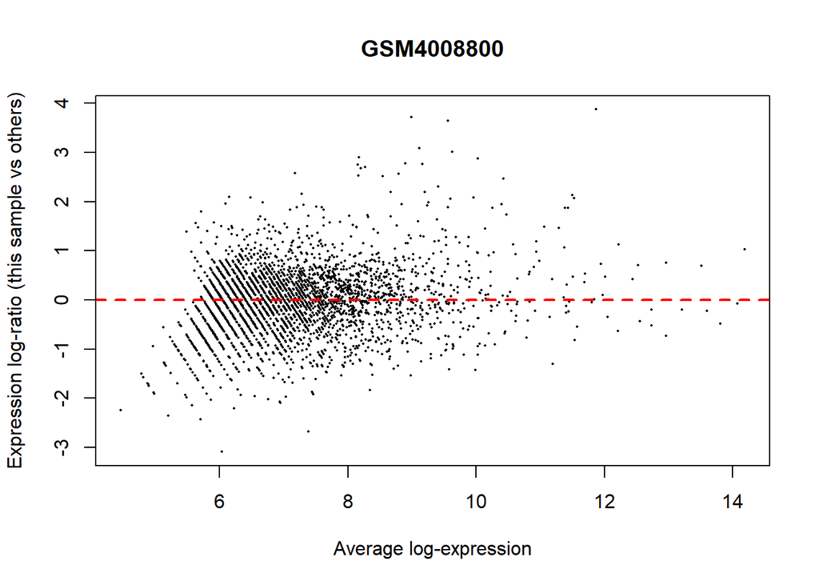

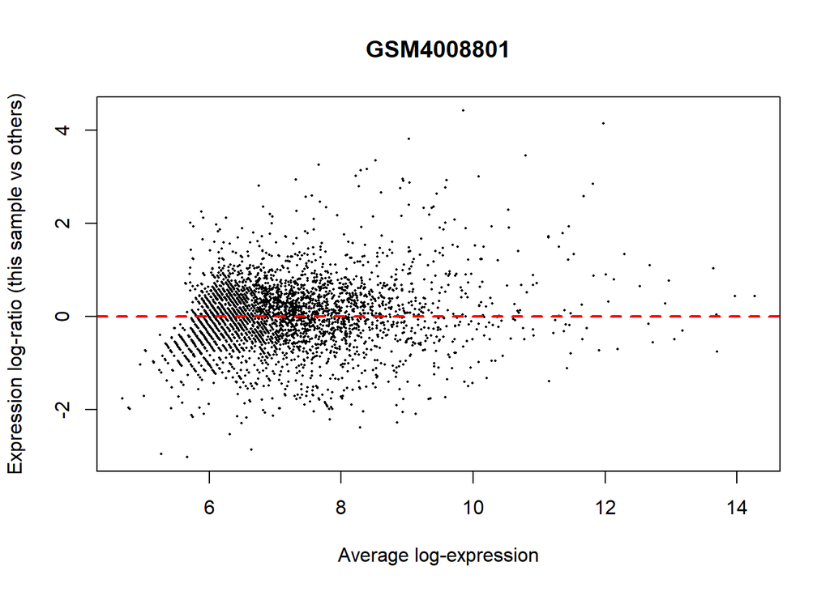

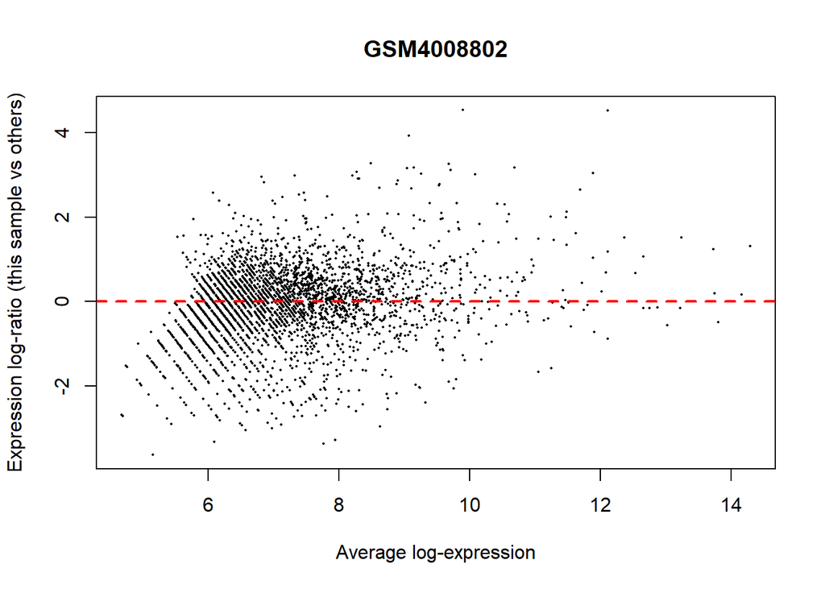

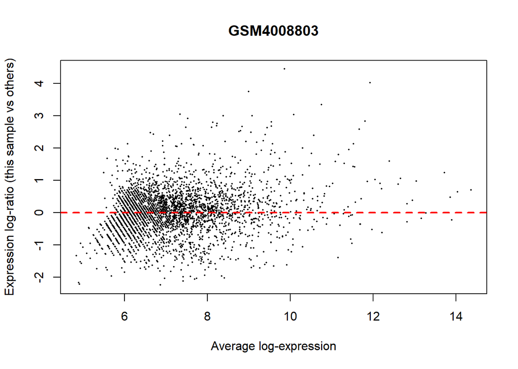

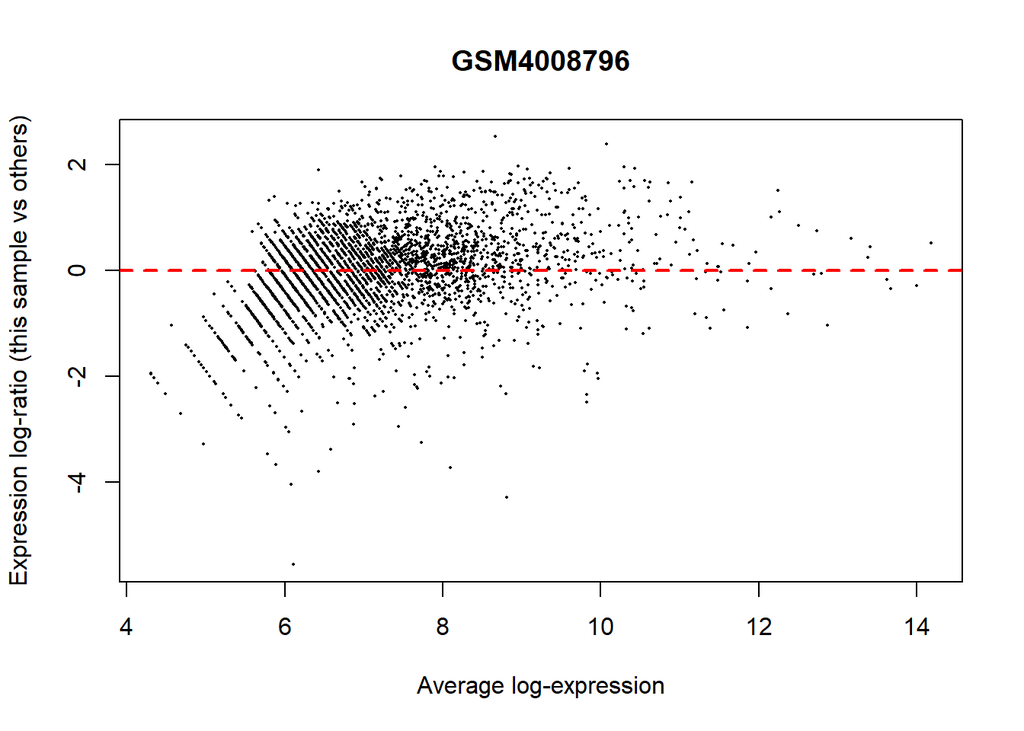

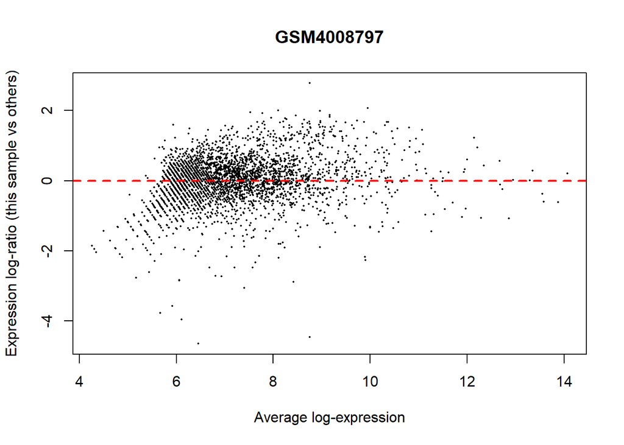

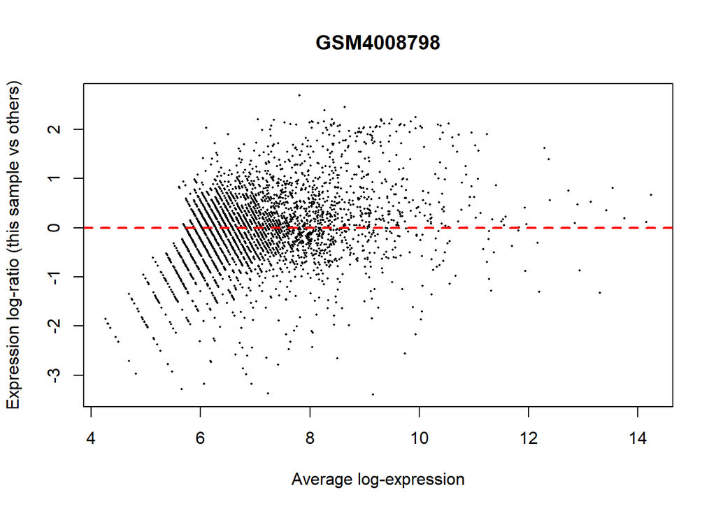

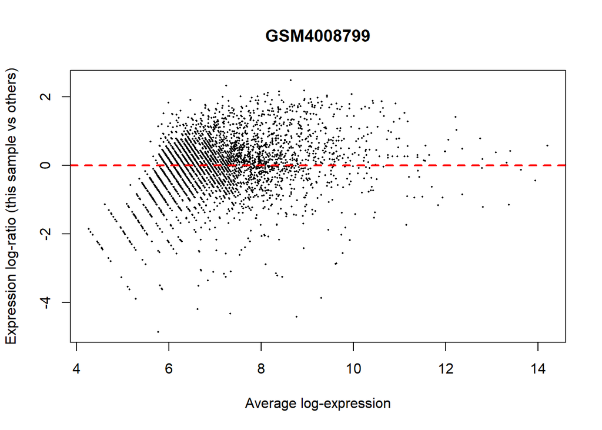

```r
for (sample in 1:nrow(y$samples)) {
  plotMD(cpm(y, log=TRUE), column=sample)
  abline(h=0, col="red", lty=2, lwd=2)
}
```

# Exploring differences between libraries

The data can be explored by generating multi-dimensional scaling (MDS) plots. This visualizes the differences between the expression profiles of different samples in two dimensions. The next plot shows the MDS plot for the yeast heatshock data.

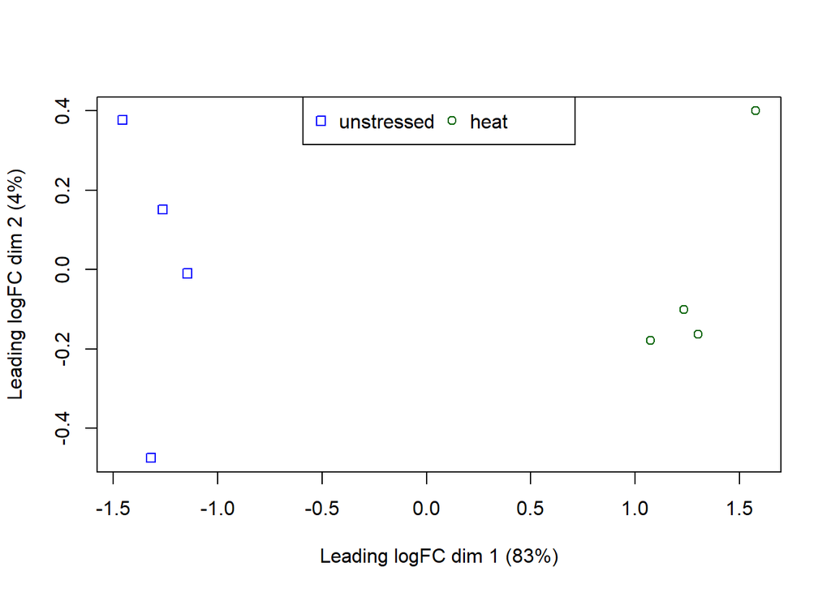

```r
points <- c(0,1,2,15,16,17)
colors <- rep(c("blue", "darkgreen", "red"), 2)
plotMDS(y, col=colors[group], pch=points[group])
legend("top", legend=levels(group),
     pch=points, col=colors, ncol=2)
```

# Estimate Dispersion

The trended NB dispersion is estimated using the estimateDisp function. This returns the DGEList object with additional entries for the estimated NB dispersions for all genes. These estimates can be visualized with plotBCV, which shows the root-estimate, i.e., the biological coefficient of variation for each gene

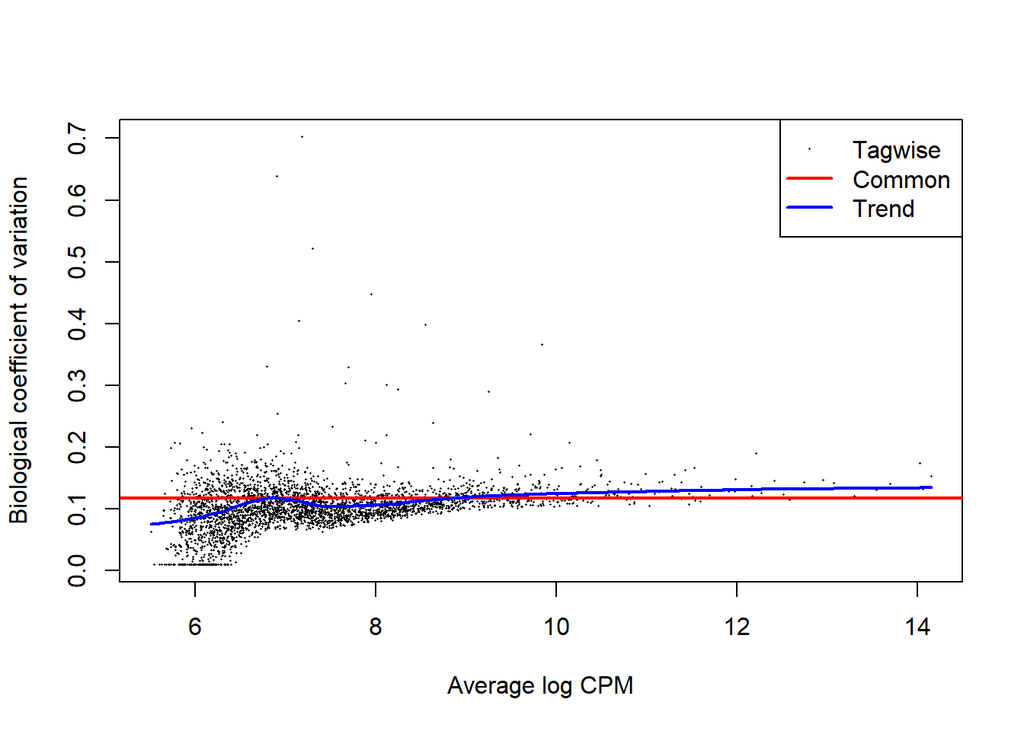

```r
y <- estimateDisp(y, design, robust=TRUE)
plotBCV(y)
```

In general, the trend in the NB dispersions should decrease smoothly with increasing abundance. This is because the expression of high-abundance genes is expected to be more stable than that of low-abundance genes. Any substantial increase at high abundances may be indicative of batch effects or trended biases. The value of the trended NB dispersions should range between 0.005 to 0.05 for laboratory-controlled biological systems like mice or cell lines, though larger values will be observed for patient-derived data (> 0.1)

For the QL dispersions, estimation can be performed using the glmQLFit function. This returns a DGEGLM object containing the estimated values of the GLM coefficients for each gene

```r
fit <- glmQLFit(y, design, robust=TRUE)
head(fit$coefficients)
```

```
##         unstressed  heat
## YDR387C      -9.65 -9.48
## YDR492W      -8.66 -9.84
## YDL189W      -8.87 -9.39
## YDR508C      -7.57 -7.36
## YDR175C      -9.95 -9.77
## YDR186C      -8.78 -8.27
```

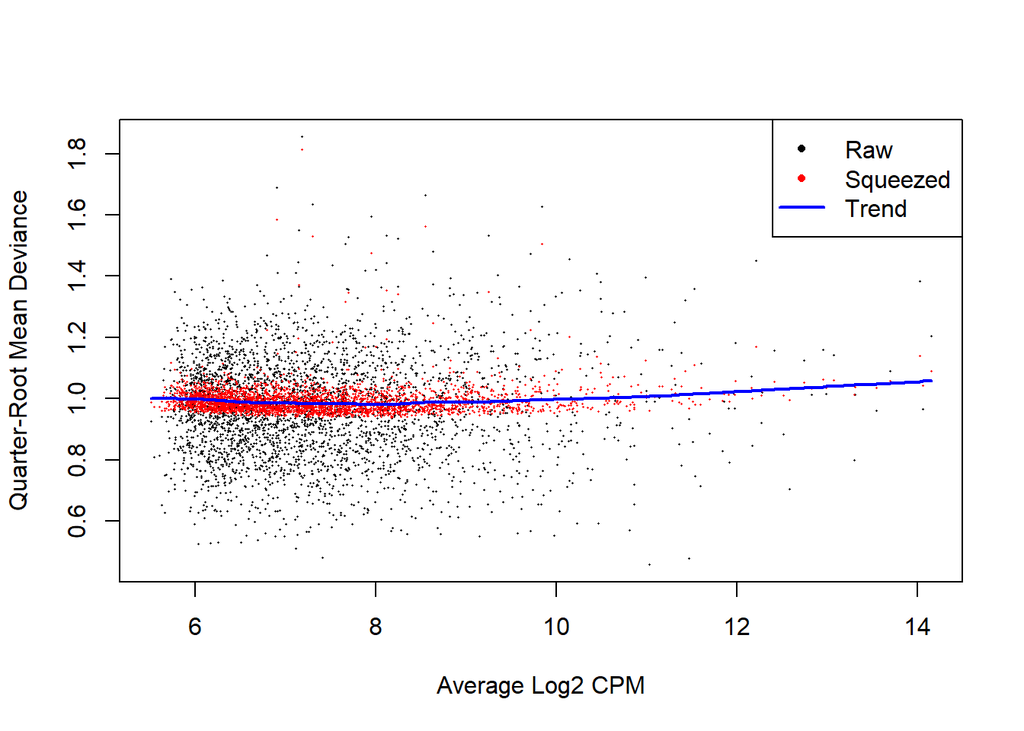

```r
plotQLDisp(fit)
```

EB squeezing of the raw dispersion estimators towards the trend reduces the uncertainty of the final estimators. The extent of this moderation is determined by the value of the prior df, as estimated from the data. Large estimates for the prior df indicate that the QL dispersions are less variable between genes, meaning that stronger EB moderation can be performed. Small values for the prior df indicate that the dispersions are highly variable, meaning that strong moderation would be inappropriate

Setting robust=TRUE in glmQLFit is strongly recommended. This causes glmQLFit to estimate a vector of df.prior values, with lower values for outlier genes and larger values for the main body of genes.

# Testing for differential expression

The final step is to actually test for significant differential expression in each gene, using the QL F-test. The contrast of interest can be specified using the makeContrasts function. Here, genes are detected that are DE between the stressed and unstressed. This is done by defining the null hypothesis as heat stressed - unstressed = 0.

```r
con <- makeContrasts(heat - unstressed, levels=design)
res <- glmQLFTest(fit, #coef="heat")
                  contrast = con)
```

```r
topTags(res, n=Inf) %>% data.frame() %>%
  arrange(desc(logFC)) %>%
  mutate(logFC=round(logFC,2)) %>%
  mutate(across(where(is.numeric), signif, 3)) %>%
  reactable()
```

|  | ORF | SGD | GENENAME | logFC | logCPM | F | PValue | FDR |
| --- | --- | --- | --- | --- | --- | --- | --- | --- |
| YBR072W | YBR072W | S000000276 | HSP26 | 7.87 | 11 | 614 | 3.59e-21 | 7.83e-19 |
| YMR174C | YMR174C | S000004786 | PAI3 | 7.48 | 6.12 | 108 | 1.4e-11 | 1.49e-10 |
| YER103W | YER103W | S000000905 | SSA4 | 7.36 | 13.1 | 1030 | 7.64e-27 | 2.5e-23 |
| YMR169C | YMR169C | S000004779 | ALD3 | 7.24 | 9.97 | 652 | 1.32e-23 | 1.08e-20 |
| YDR070C | YDR070C | S000002477 | FMP16 | 6.96 | 7.13 | 209 | 5.31e-16 | 1.48e-14 |
| YGR043C | YGR043C | S000003275 | NQM1 | 6.39 | 7.77 | 322 | 8.4e-19 | 8.04e-17 |
| YDL222C | YDL222C | S000002381 | FMP45 | 6.01 | 9.06 | 447 | 5.26e-21 | 9.06e-19 |
| YGR256W | YGR256W | S000003488 | GND2 | 5.8 | 8.73 | 447 | 5.26e-21 | 9.06e-19 |
| YHR096C | YHR096C | S000001138 | HXT5 | 5.7 | 8.76 | 462 | 3.09e-21 | 7.22e-19 |
| YLR178C | YLR178C | S000004168 | TFS1 | 5.62 | 9.68 | 674 | 7.75e-24 | 8.45e-21 |

[output cut: 3260 more lines]

```r
is.de <- decideTestsDGE(res, p.value=0.05)
summary(is.de)
```

```
##        -1*unstressed 1*heat
## Down                    902
## NotSig                 1522
## Up                      846
```

Let’s take a quick look at the differential expression

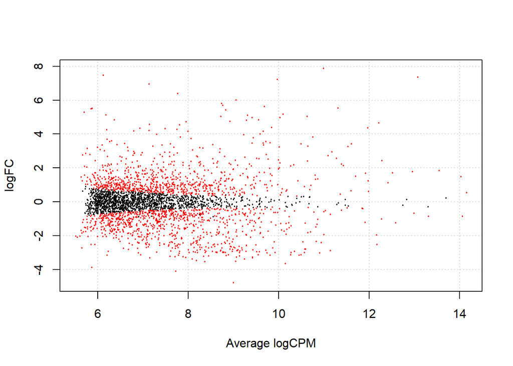

```r
plotSmear(res, de.tags=rownames(res)[is.de!=0])
```

# Gene Ontology

```r
# alias2Symbol()

# go <- goana(res, species.KEGG="sce")
# topGO(go, n=10)

kegg <- kegga(res, species.KEGG="sce", FDR=0.01,
      plot=T)

topKEGG(kegg, sort="up")
```

```
##                                                      Pathway   N  Up Down
## sce03050                                          Proteasome  35  31    0
## sce00500                       Starch and sucrose metabolism  27  20    3
## sce01200                                   Carbon metabolism  83  40   16
## sce00630             Glyoxylate and dicarboxylate metabolism  20  15    3
## sce01100                                  Metabolic pathways 545 154  137
## sce00020                           Citrate cycle (TCA cycle)  24  14    2
## sce01110               Biosynthesis of secondary metabolites 281  84   85
## sce04213     Longevity regulating pathway - multiple species  32  16    2
## sce04141         Protein processing in endoplasmic reticulum  85  32   11
## sce00620                                 Pyruvate metabolism  43  18    9
## sce00130 Ubiquinone and other terpenoid-quinone biosynthesis   6   5    1
## sce00010                        Glycolysis / Gluconeogenesis  44  17   10
## sce00410                             beta-Alanine metabolism  10   6    1
## sce00430                  Taurine and hypotaurine metabolism   3   3    0
## sce00280          Valine, leucine and isoleucine degradation  13   7    3
## sce00250         Alanine, aspartate and glutamate metabolism  29  12    5
## sce00052                                Galactose metabolism  11   6    3
## sce00310                                  Lysine degradation  14   7    2
## sce00910                                 Nitrogen metabolism   6   4    2
## sce00561                             Glycerolipid metabolism  28  11    5
##              P.Up  P.Down
## sce03050 1.71e-17 1.00000
## sce00500 5.27e-09 0.96437
## sce01200 2.89e-08 0.81939
## sce00630 3.70e-07 0.86899
## sce01100 1.17e-05 0.09074
## sce00020 7.68e-05 0.98422
## sce01110 2.17e-04 0.00164
## sce04213 2.75e-04 0.99748
## sce04141 3.33e-04 0.99321
## sce00620 1.68e-03 0.67634
## sce00130 2.11e-03 0.78932
## sce00010 6.07e-03 0.56659
## sce00410 8.55e-03 0.92554
## sce00430 9.53e-03 1.00000
## sce00280 9.69e-03 0.59906
## sce00250 1.09e-02 0.82648
## sce00052 1.55e-02 0.47646
## sce00310 1.59e-02 0.86424
## sce00910 2.09e-02 0.41431
## sce00561 2.23e-02 0.80122
```

```r
gene_data_logFC <- res$table %>% dplyr::select(logFC)


if (!requireNamespace("pathview", quietly = TRUE))
    BiocManager::install("pathview")
```

```r
library("pathview")
test <- pathview(gene.data  = gene_data_logFC,
                     # pathway.id = "sce01100", #metabolic pathways
                     pathway.id = "sce00010", #glycolysis/gluconeogenesis
                     # pathway.id = "sce03050", # proteasome cycle
                     # pathway.id = "sce00020", # TCA cycle
                     # pathway.id = "sce00500", # starch & sucrose metabolism (trehalose)
                     # pathway.id = "sce00030", #PPP
                     species    = "sce",
                     gene.idtype="orf",
                     expand.node = TRUE,
                     map.symbol = T,
                     kegg.native = F,
                     match.data = T,
                     multi.state = T,
                     bins=20,
                     same.layer = F,
                     pdf.size=c(7,7),
                     limit = list(gene=5, cpd=1))
```

```
## [1] "Note: 7 of 3270 unique input IDs unmapped."
```

```
## Info: Getting gene ID data from KEGG...
```

```
## Info: Done with data retrieval!
```

```
## Note: Gene nodes not expanded when reactions are converted to edges!
```

```
## Info: Working in directory C:/Users/makov/local/GenomicDataAnalysis_Fa23/exercises
```

```
## Info: Writing image file sce00010.pathview.pdf
```

Be sure to knit this file into a pdf or html file once you’re finished.

**R version 4.3.0 (2023-04-21 ucrt)**

**Platform:** x86_64-w64-mingw32/x64 (64-bit)

**locale:** *LC_COLLATE=English_United States.utf8*, *LC_CTYPE=English_United States.utf8*, *LC_MONETARY=English_United States.utf8*, *LC_NUMERIC=C* and *LC_TIME=English_United States.utf8*

**attached base packages:** *stats4*, *stats*, *graphics*, *grDevices*, *utils*, *datasets*, *methods* and *base*

**other attached packages:** *pathview(v.1.40.0)*, *org.Sc.sgd.db(v.3.17.0)*, *AnnotationDbi(v.1.62.2)*, *IRanges(v.2.34.0)*, *S4Vectors(v.0.38.1)*, *Biobase(v.2.60.0)*, *BiocGenerics(v.0.46.0)*, *edgeR(v.3.42.4)*, *limma(v.3.56.2)*, *reactable(v.0.4.4)*, *BiocManager(v.1.30.21)*, *pander(v.0.6.5)*, *knitr(v.1.43)*, *here(v.1.0.1)*, *lubridate(v.1.9.2)*, *forcats(v.1.0.0)*, *stringr(v.1.5.0)*, *dplyr(v.1.1.2)*, *purrr(v.1.0.1)*, *readr(v.2.1.4)*, *tidyr(v.1.3.0)*, *tibble(v.3.2.1)*, *ggplot2(v.3.4.2)* and *tidyverse(v.2.0.0)*

**loaded via a namespace (and not attached):** *tidyselect(v.1.2.0)*, *blob(v.1.2.4)*, *Biostrings(v.2.68.1)*, *bitops(v.1.0-7)*, *fastmap(v.1.1.1)*, *RCurl(v.1.98-1.12)*, *XML(v.3.99-0.14)*, *digest(v.0.6.31)*, *timechange(v.0.2.0)*, *lifecycle(v.1.0.3)*, *ellipsis(v.0.3.2)*, *KEGGgraph(v.1.60.0)*, *statmod(v.1.5.0)*, *KEGGREST(v.1.40.0)*, *RSQLite(v.2.3.1)*, *magrittr(v.2.0.3)*, *compiler(v.4.3.0)*, *rlang(v.1.1.1)*, *sass(v.0.4.7)*, *tools(v.4.3.0)*, *utf8(v.1.2.3)*, *yaml(v.2.3.7)*, *htmlwidgets(v.1.6.2)*, *curl(v.5.0.1)*, *bit(v.4.0.5)*, *withr(v.2.5.0)*, *grid(v.4.3.0)*, *fansi(v.1.0.4)*, *colorspace(v.2.1-0)*, *scales(v.1.2.1)*, *cli(v.3.6.1)*, *rmarkdown(v.2.23)*, *crayon(v.1.5.2)*, *generics(v.0.1.3)*, *rstudioapi(v.0.15.0)*, *httr(v.1.4.6)*, *tzdb(v.0.4.0)*, *DBI(v.1.1.3)*, *cachem(v.1.0.8)*, *zlibbioc(v.1.46.0)*, *splines(v.4.3.0)*, *XVector(v.0.40.0)*, *vctrs(v.0.6.2)*, *jsonlite(v.1.8.7)*, *hms(v.1.1.3)*, *bit64(v.4.0.5)*, *Rgraphviz(v.2.44.0)*, *locfit(v.1.5-9.8)*, *jquerylib(v.0.1.4)*, *glue(v.1.6.2)*, *reactR(v.0.4.4)*, *stringi(v.1.7.12)*, *gtable(v.0.3.3)*, *GenomeInfoDb(v.1.36.1)*, *munsell(v.0.5.0)*, *pillar(v.1.9.0)*, *htmltools(v.0.5.5)*, *graph(v.1.78.0)*, *GenomeInfoDbData(v.1.2.10)*, *R6(v.2.5.1)*, *rprojroot(v.2.0.3)*, *evaluate(v.0.21)*, *lattice(v.0.21-8)*, *highr(v.0.10)*, *png(v.0.1-8)*, *memoise(v.2.0.1)*, *bslib(v.0.5.0)*, *Rcpp(v.1.0.10)*, *org.Hs.eg.db(v.3.17.0)*, *xfun(v.0.39)* and *pkgconfig(v.2.0.3)*